BACK TO SCHEDULE

- The Least-Square Regression
- The Least-Square Regression in R
- Coefficient of Determination

# The Least-Squares Regression

Scatterplot with fitted line, $\hat{Y}$ = $b_o + b_1X$

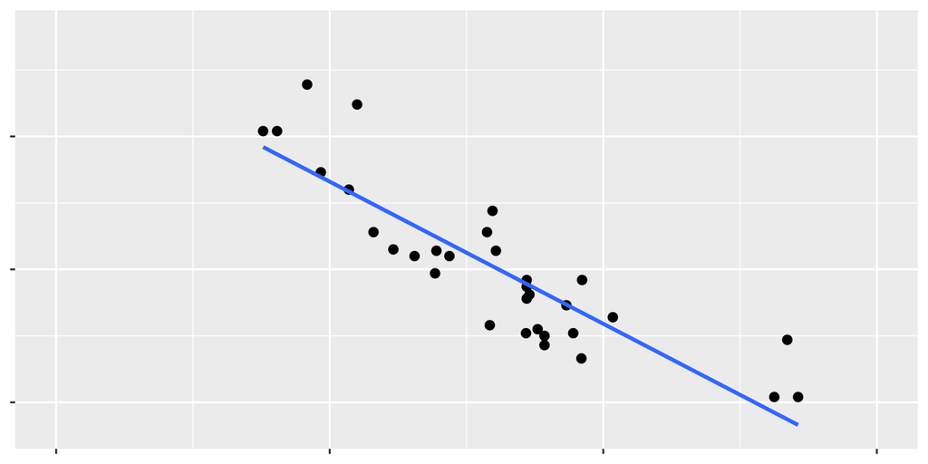

Scatterplot with linear model, Y = $b_o + b_1X$ + *residual*

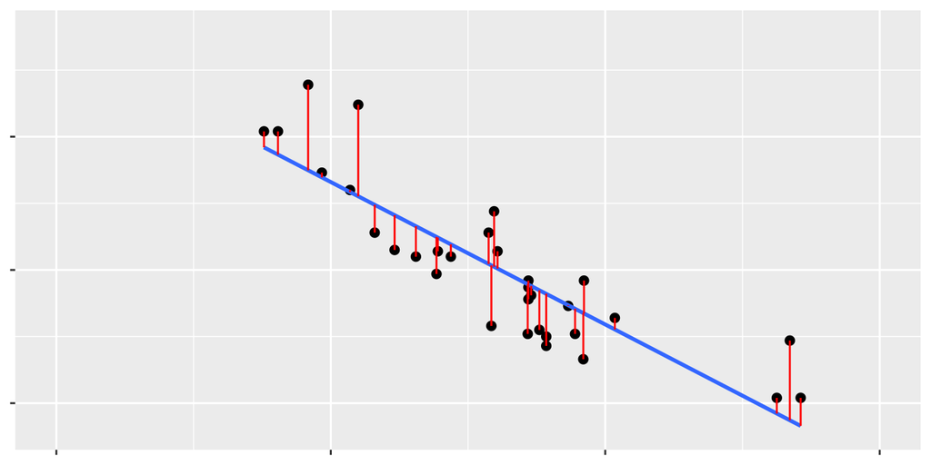

> The Least-Squares method finds $b_o$ and $b_1$ such that the sum of square residuals *(distance from points to the line)* is the minimum.

> $b_o$ is the Y-intercept, and $b_1$ is the slope.

**Formulas**

The **slope** of the line: $b_1$ = $r\frac{S_y}{S_x}$

> The coefficient of correlation is, **r**. $S_y$ and $S_x$ are the standard deviations of Y and X respectively. The $b_1$ represents the amount Y increases (or decreases) on AVERAGE for every unit increase in X

The **y-intercept** of the line: bo = $\bar{Y} - b\bar{X}$

> The $b_o$ represents the value of Y when X = 0

The residual *(error or deviation)* of any observation is given by: Y - $\hat{Y}$

> The residual measures the amount missed by $\hat{Y}$ in the prediction of Y

# The Least-Squares Regression in R

For example, fit the regression line treating cars’ weight (wt) as the independent variable and fuel efficiency (mpg) as the dependent variable.

> Step 1: Open R GUI. Type in R Console *library(Rcmdr)*

> Step 2: Open data. Click on DATA > DATA IN PACKAGES > Read data set from attached package > Enter name of data set: **mtcars**. Click OK.

> Step 3: Click on GRAPHS > SCATTERPLOT

> Step 4: Choose **wt** in x-variable and **mpg** in y-variable. Then click OK.

[output not shown]

**Interpretation**

Y-intercept = 37.285

> At *zero* pounds, the average fuel efficiency of cars is 37.285 mpg. In this context, the Y-intercept does not have any practical interpretation.

Slope = -5.344

> For every 1000 lbs, the fuel efficiency of a car decreases by 5.344 mpg on average.

*Exercise:* Determine the residual of fuel efficiency (mpg) of a Honda Civic with 30.4 mpg and actual weight of 1.615 (1000 lbs).

- Residual = Observed - Predicted = Y - $\hat{Y}$
- First, compute the predicted (or fitted) value $\hat{Y}$
- $\hat{Y}$ = 37.285 - 5.344(1.615) = 28.654
- Calculate the residual: Y - $\hat{Y}$
- Y - $\hat{Y}$ = 30.4 - 28.654 = 1.746

Is the fuel efficiency above or below the average?

- The fuel efficiency of the Honda Civic is 1.746 mpg above the average.

**Adding the fitted line to the scatterplot.**

> GRAPHS > SCATTERPLOT > Pick x-variable and y-variable > OPTIONS > Least-Squares line > OK

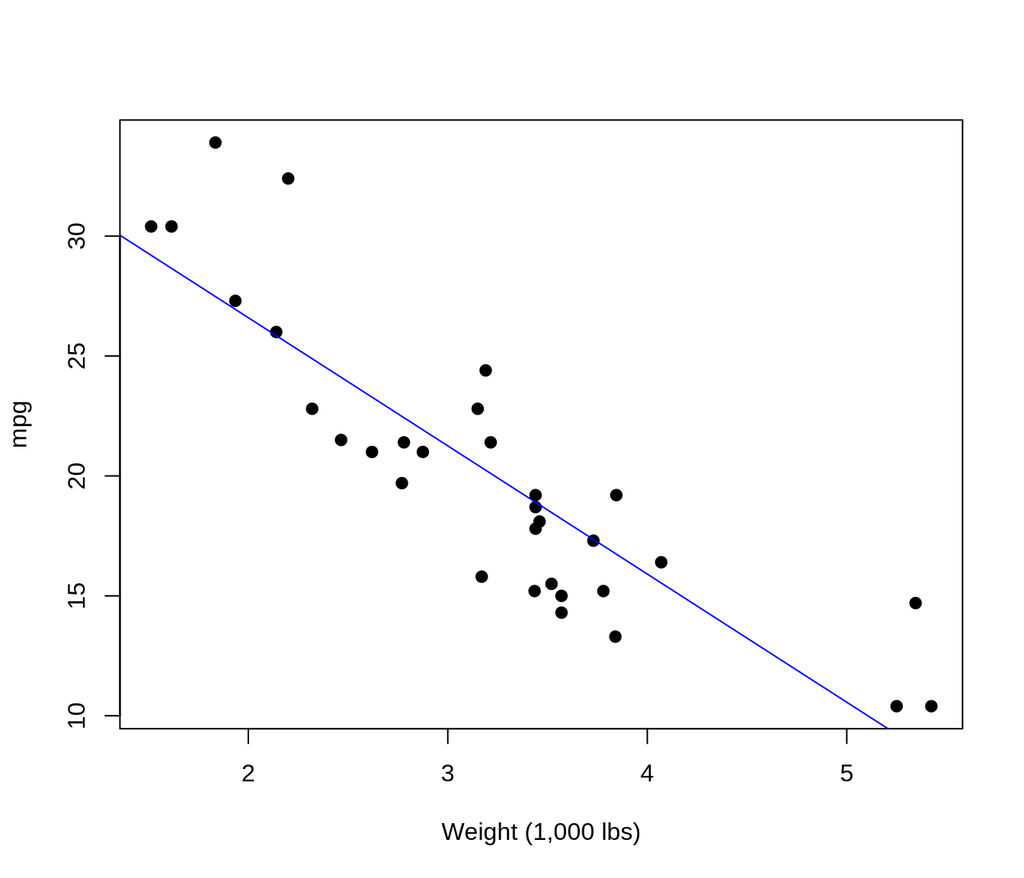

# Coefficient of Determination

- The coefficient of determination, $R^2$ can be thought as the **proportion of the total variation** in Y that can be attributed to the least-squares regression line.
- The square of the correlation coefficient *r* computes the coefficient of determination; although, they have different interpretation.
- The coefficient of determination is a number between 0 and 1.
- If $R^2$ = 0, the regression line has NO explanatory value.

Compute and interpret the coefficient of determination in the linear model between Hormone replacement therapy (HRT) and the risk of breast cancer.

| % HRT Use | 46.30 | 40.60 | 39.50 | 36.60 | 30.00 |
| --- | --- | --- | --- | --- | --- |
| Incidence | 103.30 | 105.00 | 100.00 | 93.80 | 83.50 |

**Insert Data in R**

> Open R GUI: library(Rcmdr)

> Click on Data > New data set > Enter name for data set: **HRT** > OK

> Click “Add row” five times because there are 5 observations, then click “Add column” once because we have one additional variable.

> Change the columns names from V1 and V2 to **hrtpct** and **risk** respectively.

> STATISTICS > SUMMARIES > CORRELATION MATRIX

```
[1] 0.911229
```

```r
# Coefficient of Determination
(0.9112)^2
```

```
[1] 0.8302854
```

> The linear model can explain 83% of the variability of risk of breast cancer.

**Exercise:** The table below contains data on microwave ovens found at www.target.com. *(Use the instructions given in the previous exercise to enter these data in R GUI)*

```
      price watts
 [1,]    80  1100
 [2,]    80   700
 [3,]    50   700
 [4,]    90  1200
 [5,]   100  1200
 [6,]    90  1200
 [7,]   110  1200
 [8,]    90  1000
 [9,]    75  1000
[10,]    80  1000
[11,]    63   700
```

*a)* Obtain a scatterplot using Price as the X variable and Watts as the Y variable.

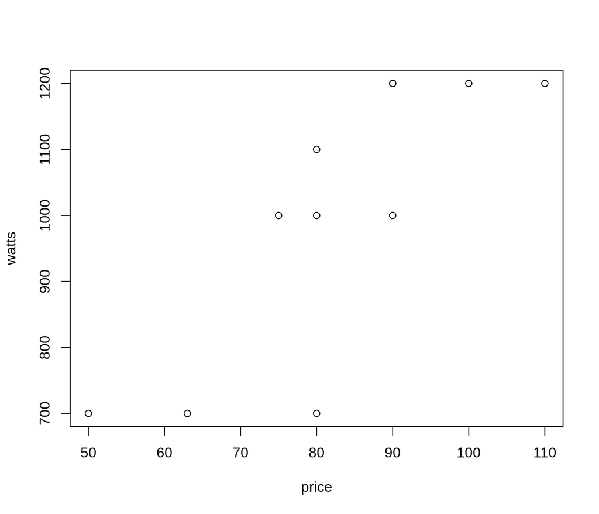

*b)* Describe the scatterplot in (a).

> There relationship appears to be positive and somewhat linear, with several unusual points.

*c)* Compute the correlation.

```
          price     watts
price 1.0000000 0.8088885
watts 0.8088885 1.0000000
```

> The correlation, r, is 0.8089. You get the same result if you change the order of the objects

*d)* What does the value of r indicate about the relationship between Price and Watts?

> There is a strong, positive linear relationship between Price and Watts. As the price of microwaves increases, the number of watts tend to increase.